# (Ford GoBike System Data)

## by (Alaa Nagy)

## Preliminary Wrangling

> This data set includes information about individual rides made in a bike-sharing system covering the greater San Francisco Bay area. Download data from [here](https://www.fordgobike.com/system-data)

### What is the structure of your dataset?

> The dataset consists of about 183412 observations(rows) and 16 features(columns)

### What is/are the main feature(s) of interest in your dataset?

> The duration of the trip, member_birth_year, member_gender and user type(customer or subsriber)

### What features in the dataset do you think will help support your investigation into your feature(s) of interest?

> I think i can see the effect of gender on user type, member_birth_year effect on user type and duation and other

## Univariate Exploration

What are the most common trips start and end stations?

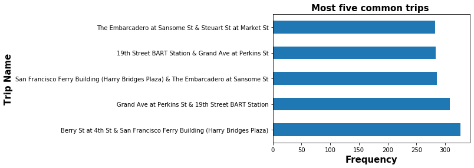

What is the percentage of different Genders in our dataset?

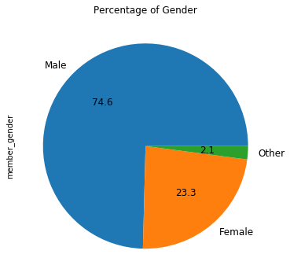

**Male gender is the most gender using bike_share system in our data with 74.6% , Female with 23.3% and Other with 2.1%**

What is the distrbution of trips during the day?

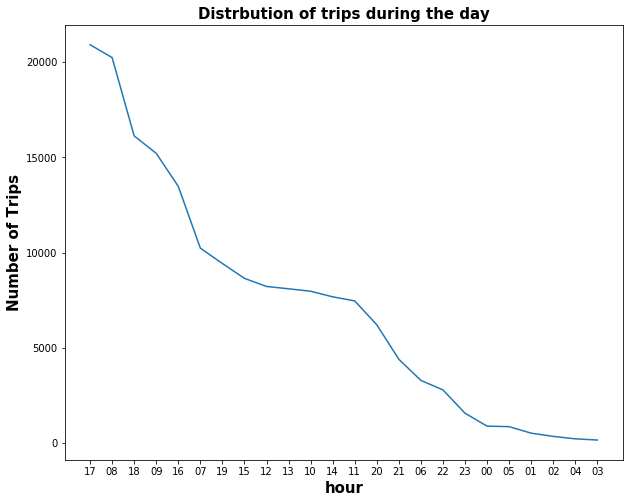

- **From the above figure, it is clear that the trips are very high at 5:00 PM and 08:00 AM which make sense as it is the time going and returning from work**
- **Trips are very low after midnight as most of people are in their homes**

What is the distrbution of trips during the week?

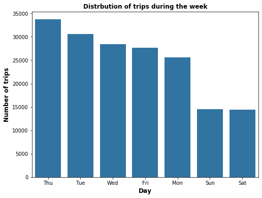

- **From the above figure, it is clear that Number of trips are high in thursday and Tuesday**
- **Number of trips are very low at weekend sunday and saturday**

How does the distrbution of trip duration looks like?

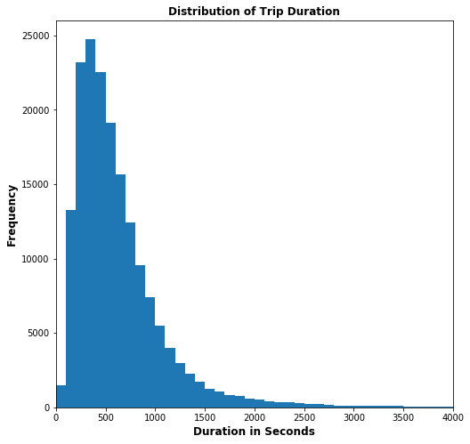

- **The Distrbution of trip duriation in seconds take the form of a plot which is right-skewed**
- **Most of trips duration are less than 1000 sec, while there are outliers bigger than 3500 and 4000 seconds**

What is the percentage of different user types in our dataset?

[figure not shown]

**Subscriber type is about 90.5% of all users of the bike-share system while customers are 9.5% only**

## Bivariate Exploration

What is the relationship between user's age and its trip duration?

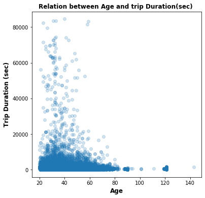

- **The figure above shows the relation between age and trip duration, and it make sense youth or younger peaple can go for long trips more than older ones**
- **It is clear that most trips have low duration**

How does the number of trips differ during the week from gender to another?

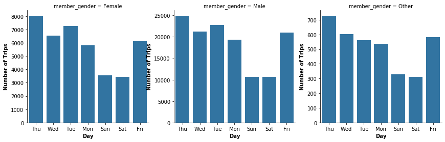

- **The figure above shows that distrbution of trips during the week for all three member_gender (Male,Female, and Other)**
- **It is clear that number of trips very high for male according to other genders(Female and Other)**
- **Thursday is the most busy one with trips and saturday and sunday are less days that had trips as it is a weekend**

What is the relationship between user type and age?

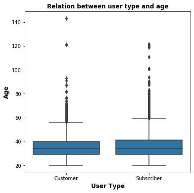

What is the Distrbution of user type for each Gender in our dataset?

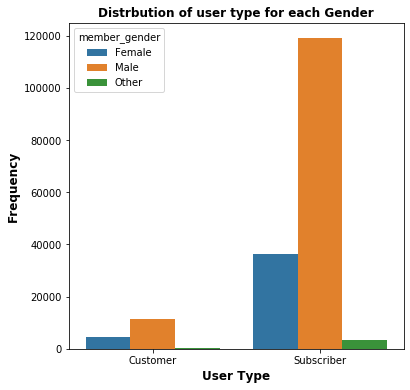

**The figure above shows that the Distrbution of user type for each Gender where Male are the most in all types (subscriber or Customer), that make sense as Male Gender about 75% of users in all**

What is the relationship between trip hour and trip Duration(hr)?

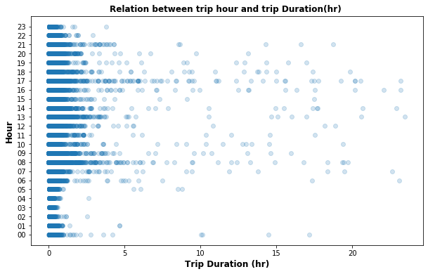

- **The Figure above shows that the relation between trip hour and trip duration in hours**
- **It is clear that the duration is large at 8am and 5pm and very low after midnight**
- **Generally, the trip duration is smallm, less than 5 hours**
- **There are outliers in this scatter plot**

## Multivariate Exploration

How is trip duration differ during the week for different user type?

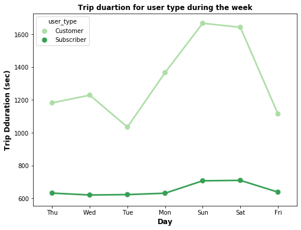

**From the figure above, it is clear that Customer type tend to has more trip duration than subscriber during all days in the week**

What is the relationship between Trip duration (hr) and age for different genders?

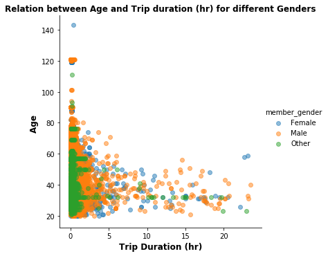

What are the number of trips during the week for different user tpyes and genders?

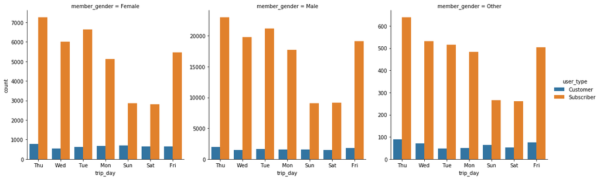

- **The figure above shows the relation propotion between user type (customer and subscriber) for all genders (male, female and other) during the week**
- **from the three plots, it is clear that subscriber is more than customer for all genders and numbers in male are higher generally**

How does the trip duration differ during the week for different genders?

[figure not shown]